# Week 9 — Optional Notebook

Intuition Before the Maths

Author

Tom Hackenberg · Block 2

Published

March 30, 2025

> **This notebook is optional.** Nothing here is required for the exam. It exists for students who want to build intuition early — and for the curious, to get hands-on with the tools before the lectures build on them. Most cells take under a second to run.

## Environment setup — start here

If you have not already set up the course environment, follow the instructions in the repo `README.md` before running this notebook. The short version:

**First time (start of block):**

```bash
# Install uv — Mac/Linux
curl -LsSf https://astral.sh/uv/install.sh | sh

# Then in the repo root
uv sync
```

**Every time you open a notebook:**

```bash
quarto preview week09/week09_notebook.qmd
```

That is it. `uv sync` created a `.venv/` folder in the repo root, and `_quarto.yml` tells Quarto to use it automatically — no activation step needed.

## What this notebook covers

**Part 1 — Simpson’s Paradox** *(~20 min)* A reminder that aggregated data lies. We build the paradox from scratch, visualise it, and end on the question that Week 11 will answer.

**Part 2 — The Naïve OLS Problem** *(~25 min)* We generate a simple synthetic dataset, fit a naïve OLS in Python, and watch a coefficient we should not trust look very convincing. This is the number Week 12 will explain.

**Note**

**On language.** This course is method-agnostic — notebooks will use both Python and R across the block. This particular notebook is Python only. The exam will not test syntax.

# Part 1 — Simpson’s Paradox

## The setup

Suppose a firm runs two ad campaigns — one targeting **budget** customers, one targeting **premium** customers — and measures conversion rates.

This is Simpson’s Paradox: a trend that appears in aggregated data reverses — or disappears — when the data is disaggregated. It is not a data error. It is a structural feature of how the groups are mixed.

Let’s build it.

```python
import numpy as np
import pandas as pd
import statsmodels.api as sm
import matplotlib.pyplot as plt
import matplotlib.patches as mpatches

rng = np.random.default_rng(42)
```

```python
# --- Budget segment ---
# Small group, low baseline conversion, Campaign A assigned
n_budget = 200
budget = pd.DataFrame({
    "segment":    "Budget",
    "campaign":   "A",
    "conversion": rng.binomial(1, 0.18, n_budget)   # 18% base rate
})

# --- Premium segment ---
# Large group, high baseline conversion, Campaign B assigned
n_premium = 800
premium = pd.DataFrame({
    "segment":    "Premium",
    "campaign":   "B",
    "conversion": rng.binomial(1, 0.62, n_premium)  # 62% base rate
})

# Add campaign lift: A is genuinely 8pp better in both segments
budget.loc[budget.campaign == "A",    "conversion"] = (
    rng.binomial(1, 0.26, n_budget))   # 18 + 8
premium.loc[premium.campaign == "B",  "conversion"] = (
    rng.binomial(1, 0.62, n_premium))  # no lift — B is the control here

# Combine
df = pd.concat([budget, premium], ignore_index=True)
```

```python
# Aggregate conversion rates
agg = df.groupby("campaign")["conversion"].mean().rename("rate").reset_index()
seg = df.groupby(["segment", "campaign"])["conversion"].mean().rename("rate").reset_index()

print("=== Aggregated (misleading) ===")
print(agg.to_string(index=False))
print()
print("=== By segment (truthful) ===")
print(seg.to_string(index=False))
```

```
=== Aggregated (misleading) ===
campaign  rate
       A 0.285
       B 0.625

=== By segment (truthful) ===
segment campaign  rate
 Budget        A 0.285
Premium        B 0.625
```

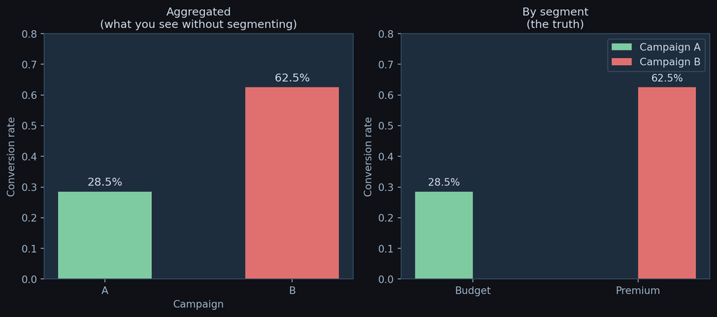

Simpson’s Paradox — aggregated vs. segmented conversion rates

```python
fig, axes = plt.subplots(1, 2, figsize=(10, 4.5), facecolor="#0f1117")

palette = {"A": "#7ecba1", "B": "#e07070"}

for ax in axes:
    ax.set_facecolor("#1e2d3d")
    for spine in ax.spines.values():
        spine.set_edgecolor("#3a5068")
    ax.tick_params(colors="#a0b4c8")
    ax.yaxis.label.set_color("#a0b4c8")
    ax.xaxis.label.set_color("#a0b4c8")
    ax.title.set_color("#d0dce8")

# Left: aggregated
ax = axes[0]
bars = ax.bar(agg["campaign"], agg["rate"],
              color=[palette[c] for c in agg["campaign"]], width=0.5)
ax.set_title("Aggregated\n(what you see without segmenting)", fontsize=11)
ax.set_ylabel("Conversion rate")
ax.set_ylim(0, 0.8)
ax.set_xlabel("Campaign")
for bar, val in zip(bars, agg["rate"]):
    ax.text(bar.get_x() + bar.get_width() / 2, val + 0.02,
            f"{val:.1%}", ha="center", color="#d0dce8", fontsize=11)

# Right: segmented
ax = axes[1]
x = np.arange(2)
segs  = ["Budget", "Premium"]
width = 0.35
for i, camp in enumerate(["A", "B"]):
    vals = [seg.loc[(seg.segment == s) & (seg.campaign == camp), "rate"].values
            for s in segs]
    vals = [v[0] if len(v) else 0 for v in vals]
    bars = ax.bar(x + i * width, vals, width, label=f"Campaign {camp}",
                  color=palette[camp])
    for bar, val in zip(bars, vals):
        if val > 0:
            ax.text(bar.get_x() + bar.get_width() / 2, val + 0.02,
                    f"{val:.1%}", ha="center", color="#d0dce8", fontsize=10)

ax.set_title("By segment\n(the truth)", fontsize=11)
ax.set_xticks(x + width / 2)
ax.set_xticklabels(segs)
ax.set_ylabel("Conversion rate")
ax.set_ylim(0, 0.8)
ax.legend(facecolor="#1e2d3d", labelcolor="#d0dce8", edgecolor="#3a5068")

plt.tight_layout()
plt.savefig("simpson_plot.png", dpi=130, bbox_inches="tight",
            facecolor=fig.get_facecolor())
plt.show()
```

## What’s actually going on — the DAG

The paradox has a clean causal explanation. Customer segment drives *both* which campaign a customer was assigned to (confounding the comparison) *and* their baseline conversion rate. Segment is a confounder.

We can draw this precisely using `networkx`.

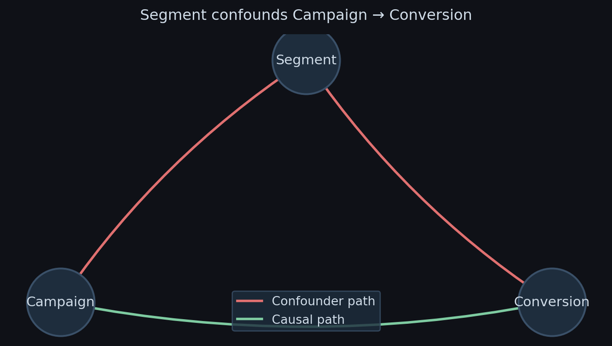

DAG — customer segment confounds the campaign–conversion relationship

```python
import networkx as nx

G = nx.DiGraph()
G.add_edges_from([
    ("Segment", "Campaign"),
    ("Segment", "Conversion"),
    ("Campaign", "Conversion"),
])

pos = {"Segment": (0, 1), "Campaign": (-1, 0), "Conversion": (1, 0)}

fig, ax = plt.subplots(figsize=(7, 4), facecolor="#0f1117")
ax.set_facecolor("#0f1117")
ax.axis("off")

# Separate confounder edges from causal edge
confounder_edges = [("Segment", "Campaign"), ("Segment", "Conversion")]
causal_edges     = [("Campaign", "Conversion")]

nx.draw_networkx_edges(G, pos, edgelist=confounder_edges,
                       edge_color="#e07070", width=2.0,
                       arrows=True, arrowsize=20,
                       connectionstyle="arc3,rad=0.1", ax=ax)
nx.draw_networkx_edges(G, pos, edgelist=causal_edges,
                       edge_color="#7ecba1", width=2.0,
                       arrows=True, arrowsize=20,
                       connectionstyle="arc3,rad=0.1", ax=ax)
nx.draw_networkx_nodes(G, pos, node_color="#1e2d3d",
                       edgecolors="#3a5068", node_size=3000,
                       linewidths=1.5, ax=ax)
nx.draw_networkx_labels(G, pos, font_color="#d0dce8",
                        font_size=11, font_family="sans-serif", ax=ax)

ax.set_title("Segment confounds Campaign → Conversion",
             color="#d0dce8", fontsize=12, pad=12)

legend_elements = [
    plt.Line2D([0], [0], color="#e07070", linewidth=2, label="Confounder path"),
    plt.Line2D([0], [0], color="#7ecba1", linewidth=2, label="Causal path"),
]
ax.legend(handles=legend_elements, facecolor="#1e2d3d",
          labelcolor="#d0dce8", edgecolor="#3a5068", loc="lower center")

plt.tight_layout()
plt.show()
```

The backdoor path is `Campaign ← Segment → Conversion`. As long as that path is open — i.e. as long as we do not condition on Segment — the raw comparison between campaigns is contaminated.

## The question this raises

We fixed the paradox by conditioning on one obvious confounder. But:

- What if we had dozens of confounders, some correlated with each other?
- What if conditioning on segment isn’t enough — because segment has a non-linear effect?
- What if we had so many control variables that OLS became unreliable?

These are exactly the questions Week 11 and 12 address. For now, the takeaway is simple:

**Important**

**Aggregated rates lie when groups differ systematically.** The fix is to condition on the confounder — but “conditioning on” needs to be done carefully. That is what the rest of Block 2 is about.

# Part 2 — The Naïve OLS Problem

## The synthetic dataset

We generate data from a known data-generating process — so we know the *true* causal effect. We then fit naïve OLS and observe how far off it is.

**The DGP:**

- $W$ = product quality (the confounder)
- $T$ = ad spend, driven partly by quality: firms with better products advertise more
- $Y$ = sales, driven by quality directly *and* by ad spend causally
- True causal effect of ad spend on sales: **τ = 1.5** (£1 of ad spend → £1.50 of sales)

```python
rng = np.random.default_rng(99)
n   = 500

# Confounder: product quality, standardised
W = rng.normal(0, 1, n)

# Treatment: ad spend — quality firms spend more
T = 2.0 * W + rng.normal(0, 1, n)

# Outcome: sales
# True effect of T on Y = 1.5
# Quality also drives sales directly (gamma = 3.0)
tau_true = 1.5
Y = tau_true * T + 3.0 * W + rng.normal(0, 1, n)

data = pd.DataFrame({"W": W, "T": T, "Y": Y})
print(data.describe().round(2))
```

```
            W       T       Y
count  500.00  500.00  500.00
mean     0.02    0.02    0.11
std      1.02    2.26    6.45
min     -3.16   -7.08  -21.09
25%     -0.68   -1.28   -3.98
50%      0.08    0.15    0.36
75%      0.69    1.42    4.32
max      3.01    6.54   18.89
```

## Naïve OLS — ignoring the confounder

A researcher who doesn’t know about $W$ (or ignores it) runs the simple regression $Y \sim T$.

```python
X_naive = sm.add_constant(data["T"])
model_naive = sm.OLS(data["Y"], X_naive).fit()
print(model_naive.summary().tables[1])
```

```
==============================================================================
                 coef    std err          t      P>|t|      [0.025      0.975]
------------------------------------------------------------------------------
const          0.0511      0.075      0.682      0.496      -0.096       0.198
T              2.7513      0.033     82.961      0.000       2.686       2.816
==============================================================================
```

```python
tau_naive = model_naive.params["T"]
print(f"True τ:       {tau_true:.2f}")
print(f"Naïve OLS τ̂: {tau_naive:.2f}  ({'overestimate' if tau_naive > tau_true else 'underestimate'})")
print(f"Bias:          {tau_naive - tau_true:+.2f}")
```

```
True τ:       1.50
Naïve OLS τ̂: 2.75  (overestimate)
Bias:          +1.25
```

The naïve estimate is substantially above the true effect. The t-statistic is large, the p-value is tiny, the confidence interval is tight — and the estimate is *wrong*. Nothing in the regression output flags the problem.

## OLS with the confounder — the correct baseline

If we observe $W$ and include it, OLS recovers the true effect.

```python
X_ctrl = sm.add_constant(data[["T", "W"]])
model_ctrl = sm.OLS(data["Y"], X_ctrl).fit()

tau_ctrl = model_ctrl.params["T"]
print(f"True τ:            {tau_true:.2f}")
print(f"Naïve OLS τ̂:      {tau_naive:.2f}")
print(f"Controlled OLS τ̂: {tau_ctrl:.2f}")
```

```
True τ:            1.50
Naïve OLS τ̂:      2.75
Controlled OLS τ̂: 1.50
```

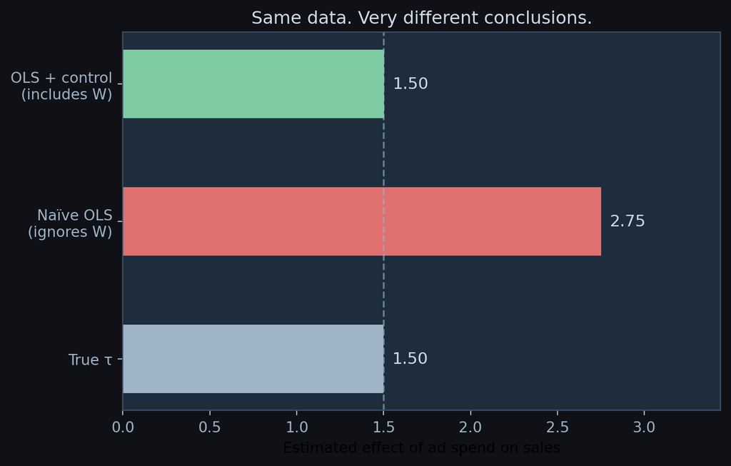

Naïve vs. controlled OLS — both look precise; only one is right

```python
fig, ax = plt.subplots(figsize=(7, 4.5), facecolor="#0f1117")
ax.set_facecolor("#1e2d3d")
for spine in ax.spines.values():
    spine.set_edgecolor("#3a5068")
ax.tick_params(colors="#a0b4c8")
ax.yaxis.label.set_color("#a0b4c8")
ax.title.set_color("#d0dce8")

labels = ["True τ", "Naïve OLS\n(ignores W)", "OLS + control\n(includes W)"]
values = [tau_true, tau_naive, tau_ctrl]
colors = ["#a0b4c8", "#e07070", "#7ecba1"]

bars = ax.barh(labels, values, color=colors, height=0.5)
ax.axvline(tau_true, color="#a0b4c8", linestyle="--", linewidth=1.2, alpha=0.6)

for bar, val in zip(bars, values):
    ax.text(val + 0.05, bar.get_y() + bar.get_height() / 2,
            f"{val:.2f}", va="center", color="#d0dce8", fontsize=11)

ax.set_xlabel("Estimated effect of ad spend on sales")
ax.set_title("Same data. Very different conclusions.", fontsize=12)
ax.set_xlim(0, max(values) * 1.25)

plt.tight_layout()
plt.savefig("ols_comparison.png", dpi=130, bbox_inches="tight",
            facecolor=fig.get_facecolor())
plt.show()
```

## The uncomfortable punchline

In this synthetic example we *knew* $W$ existed and included it. In real marketing data:

- You rarely observe product quality directly
- There may be dozens of confounders, correlated with each other
- Some effects may be non-linear — so including $W$ in OLS isn’t enough even if you observe it

The naïve OLS number ($\hat{\tau} \approx$ 2.75) looks authoritative. It has small standard errors, a significant p-value, and a plausible story. **It is wrong by design.**

Week 11 will show you exactly *what* OLS does when it “controls for” a confounder — and where that breaks down. Week 12 will show you how to fix it.

**Tip**

**If you want to get ahead:** Before we mathematically define what OLS is doing with the Frisch-Waugh-Lovell theorem in Week 11, check out the **Week 10 Easter Break Notebook**. It will show you exactly why we cannot just throw Machine Learning (like LASSO) at this problem and call it a day.

*Slides and the Week 10 notebook will be posted to GitHub.*